# Transformations and Custom Contrasts

The content of this vignette requires `marginaleffects` version 0.5.1 which was not yet available on CRAN at the time of writing. [You can always install the development version from github.](https://vincentarelbundock.github.io/marginaleffects/#installation)

This vignette explains how to create custom contrasts and slopes, and how to transform predictions, contrasts, and slopes using arbirary functions.

[The Contrasts vignette](https://vincentarelbundock.github.io/marginaleffects/articles/contrasts.html) defined contrasts as:

> The difference between two adjusted predictions.

# Transformations

This vignette shows how to move beyond such simple differences, by estimating “contrasts” that consist of ratios or arbitrary functions of adjusted predictions. It also shows how to back-transform contrasts to change their scales.

Powerful transformations and custom contrasts are made possible by using three arguments which act at different stages of the computation process:

- `transform_pre`
- `transform_post`
- `transform_avg`

Consider the case of a model with a single predictor $x$. To compute average contrasts, we proceed as follows:

1. Compute adjusted predictions for each row of the dataset for the observed values $x$: $\hat{y}_x$
2. Compute adjusted predictions for each row of the dataset for the observed values $x + 1$: $\hat{y}_{x+1}$
3. `transform_pre`: Compute unit-level contrasts by taking the difference between (or some other function of) adjusted predictions: $\hat{y}_{x+1} - \hat{y}_x$
4. `transform_post`: Transform the unit-level contrasts or return them as-is.
5. Compute the average contrast by taking the mean of unit-level contrasts: $1/N \sum_{i=1}^N \hat{y}_{x+1} - \hat{y}_x$
6. `transform_avg`: Transform the average contrast or return them as-is.

The `transform_pre` argument of the `comparisons()` function determines how adjusted predictions are combined to create a contrast. By default, we take a simple difference between predictions with `hi` value of $x$, and predictions with a `lo` value of $x$: `function(hi, lo) hi-lo`.

The `transform_post` argument of the `comparisons()` function applies a custom transformation to the unit-level contrasts.

The `transform_avg` argument is available in the `tidy()` and `summary()` functions. It applies a custom transformation to the average contrast.

The difference between `transform_post` and `transform_avg` is that the former is applied *before* we take the average, and the latter is applied *to the average*. This seems like a subtle distinction, but it can be important practical implications, since a function of the average is rarely the same as the average of a function:

```r
set.seed(1024)
x <- rnorm(100)
exp(mean(x))
```

```
#> [1] 0.9806912
```

```r
mean(exp(x))
```

```
#> [1] 1.587238
```

This vignette shows how to modify steps 3, 4, and 6 to compute custom contrasts and back transformations: Adjusted Risk Ratios (ARR), Adjusted Risk Differences (ARD), Log-Normal Hurdle Models.

# Differences

The default contrast calculate by the `comparisons()` function is a (untransformed) difference between two adjusted predictions. For instance, to estimate the effect of a change of 1 unit, we do:

```r
library(marginaleffects)
library(magrittr)

mod <- glm(vs ~ mpg, data = mtcars, family = binomial)

# construct data

mtcars_minus <- mtcars_plus <- mtcars
mtcars_minus$mpg <- mtcars_minus$mpg - 0.5
mtcars_plus$mpg <- mtcars_plus$mpg + 0.5

# adjusted predictions
yhat_minus <- predict(mod, newdata = mtcars_minus, type = "response")
yhat_plus <- predict(mod, newdata = mtcars_plus, type = "response")

# unit-level contrasts
con <- yhat_plus - yhat_minus

# average contrasts
mean(con)
```

```
#> [1] 0.05540227
```

We can use the `comparisons()` and `summary()` functions to obtain the same results:

```r
con <- comparisons(mod)
summary(con)
```

```
#>   Term    Contrast Effect Std. Error z value   Pr(>|z|)   2.5 %  97.5 %
#> 1  mpg (x + 1) - x 0.0554   0.008327   6.653 2.8699e-11 0.03908 0.07172
#>
#> Model type:  glm
#> Prediction type:  response
```

# Ratios

Instead of taking simple differences between adjusted predictions, it can sometimes be useful to compute other forms of contrasts. For example, [the `adjrr` function the `Stata` software package](https://journals.sagepub.com/doi/pdf/10.1177/1536867X1301300304) can compute “adjusted risk ratios”, which are ratios of adjusted predictions. To do this in `R`, we use the `transform_pre` argument:

```r
comparisons(mod, transform_pre = "ratio") %>% summary()
```

```
#>   Term    Contrast Effect Std. Error z value   Pr(>|z|) 2.5 % 97.5 %
#> 1  mpg (x + 1) / x  1.287     0.1328   9.697 < 2.22e-16 1.027  1.548
#>
#> Model type:  glm
#> Prediction type:  response
```

This result is the average adjusted risk ratio, that is, the adjusted predictions when the `mpg` are incremented by 1, divided by the adjusted predictions when `mpg` is at its original value.

The `transform_pre` accepts different values for common types of contrasts: ‘difference’, ‘ratio’, ‘lnratio’, ‘ratioavg’, ‘lnratioavg’, ‘lnoravg’, ‘differenceavg’. These strings are shortcuts for functions that accept two vectors of adjusted predictions and returns a single vector of contrasts. For example, these two commands yield identical results:

```r
comparisons(mod, transform_pre = "ratio") %>% summary()
```

```
#>   Term    Contrast Effect Std. Error z value   Pr(>|z|) 2.5 % 97.5 %
#> 1  mpg (x + 1) / x  1.287     0.1328   9.697 < 2.22e-16 1.027  1.548
#>
#> Model type:  glm
#> Prediction type:  response
```

```r
comparisons(mod, transform_pre = function(hi, lo) hi / lo) %>% summary()
```

```
#>   Term Contrast Effect Std. Error z value   Pr(>|z|) 2.5 % 97.5 %
#> 1  mpg   custom  1.287     0.1328   9.697 < 2.22e-16 1.027  1.548
#>
#> Model type:  glm
#> Prediction type:  response
#> Pre-transformation:  function(hi, lo) hi/lo
```

This mechanism is powerful, because it lets users create fully customized contrasts. Here is a non-sensical example:

```r
comparisons(mod, transform_pre = function(hi, lo) sqrt(hi) / log(lo + 10)) %>% summary()
```

```
#>   Term Contrast Effect Std. Error z value   Pr(>|z|)  2.5 % 97.5 %
#> 1  mpg   custom 0.2641    0.02614    10.1 < 2.22e-16 0.2128 0.3153
#>
#> Model type:  glm
#> Prediction type:  response
#> Pre-transformation:  function(hi, lo) sqrt(hi)/log(lo + 10)
```

The same arguments work in the plotting function `plot_cco()` as well, which allows us to plot various custom contrasts. Here is a comparison of Adjusted Risk Ratio and Adjusted Risk Difference in a model of the probability of survival aboard the Titanic:

```r
library(ggplot2)
library(patchwork)
titanic <- "https://vincentarelbundock.github.io/Rdatasets/csv/Stat2Data/Titanic.csv"
titanic <- read.csv(titanic)
mod_titanic <- glm(
    Survived ~ Sex * PClass + Age + I(Age^2),
    family = binomial,
    data = titanic)

cmp <- comparisons(mod_titanic)
summary(cmp)
```

```
#>     Term      Contrast    Effect Std. Error z value   Pr(>|z|)     2.5 %
#> 1    Sex male - female -0.484676   0.030607 -15.835 < 2.22e-16 -0.544665
#> 2 PClass     2nd - 1st -0.205782   0.039374  -5.226 1.7296e-07 -0.282954
#> 3 PClass     3rd - 1st -0.404283   0.039839 -10.148 < 2.22e-16 -0.482367
#> 4    Age   (x + 1) - x -0.006504   0.001072  -6.069 1.2904e-09 -0.008605
#>      97.5 %
#> 1 -0.424687
#> 2 -0.128609
#> 3 -0.326199
#> 4 -0.004403
#>
#> Model type:  glm
#> Prediction type:  response
```

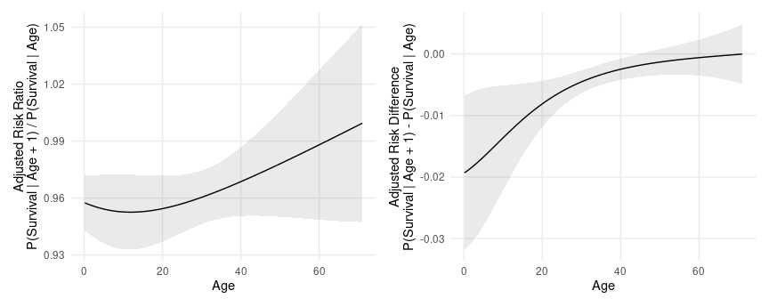

```r
p1 <- plot_cco(
    mod_titanic,
    effect = "Age",
    condition = "Age",
    transform_pre = "ratio") +
    ylab("Adjusted Risk Ratio\nP(Survival | Age + 1) / P(Survival | Age)")

p2 <- plot_cco(
    mod_titanic,
    effect = "Age",
    condition = "Age") +
    ylab("Adjusted Risk Difference\nP(Survival | Age + 1) - P(Survival | Age)")

p1 + p2
```

# Back transform: Ratios

By default, the standard errors are computed using the delta method on the scale determined by the `type` argument (e.g., “link” or “response”). Some analysts may prefer to proceed differently. For example, in `Stata`, the `adjrr` computes adjusted risk ratios (ARR) in two steps:

1. Compute the natural log of the ratio between the mean of adjusted predictions with $x+1$ and the mean of adjusted predictions with $x$.
2. Exponentiate the estimate and confidence interval bounds.

Step 1 is easy to achieve with the `transform_pre` argument described above. Step 2 can be achieved with the `transform_post` argument:

```r
comparisons(
    mod,
    transform_pre = function(hi, lo) log(mean(hi) / mean(lo)),
    transform_post = exp) %>%
    summary()
```

```
#>   Term Contrast Effect   Pr(>|z|) 2.5 % 97.5 %
#> 1  mpg   custom  1.135 2.3808e-10 1.091   1.18
#>
#> Model type:  glm
#> Prediction type:  response
#> Pre-transformation:  function(hi, lo) log(mean(hi)/mean(lo))
#> Post-transformation:  exp
```

Note that we can use the `lnratioavg` shortcut instead of defining the function ourselves.

The order of operations in previous command was:

1. Compute the custom unit-level contrasts
2. Exponentiate them
3. Take the average using the `summary()` function

There is a very subtle difference between the procedure above and this code:

```r
comparisons(
    mod,
    transform_pre = "lnratioavg") %>%
    summary(transform_avg = exp)
```

```
#>   Term                  Contrast Effect   Pr(>|z|) 2.5 % 97.5 %
#> 1  mpg ln(mean(x + 1) / mean(x))  1.135 2.3808e-10 1.091   1.18
#>
#> Model type:  glm
#> Prediction type:  response
#> Average-transformation:
```

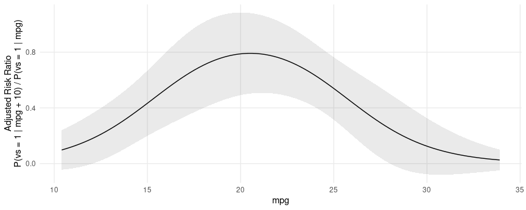

```r
library(ggplot2)

mod2 <- glm(vs ~ mpg + mpg^2, data = mtcars, family = binomial)

plot_cco(
    mod2,
    effect = list("mpg" = 10),
    condition = "mpg",
    transformation_pre = "ratio") +
    ylab("Adjusted Risk Ratio\nP(vs = 1 | mpg + 10) / P(vs = 1 | mpg)")
```

# Back transform: lognormal hurdle

With hurdle models, we can fit two separate models simultaneously:

1. A model that predicts if the outcome is zero or not zero
2. If the outcome is not zero, a model that predicts what the value of the outcome is

We can calculate predictions and marginal effects for each of these hurdle model processes, but doing so requires some variable transformation since the stages of these models use different link functions.

The `hurdle_lognormal()` family in `brms` uses logistic regression (with a logit link) for the hurdle part of the model and lognormal regression (where the outcome is logged before getting used in the model) for the non-hurdled part. Let’s look at an example of predicting GDP per capita (which is distributed exponentially) using life expectancy. We’ll add some artificial zeros so that we can work with a hurdle stage of the model.

```r
library(dplyr)
library(ggplot2)
library(patchwork)
library(brms)
library(marginaleffects)
library(gapminder)

# Build some 0s into the GDP column
set.seed(1234)
gapminder <- gapminder::gapminder %>%
  filter(continent != "Oceania") %>%
  # Make a bunch of GDP values 0
  mutate(prob_zero = ifelse(lifeExp < 50, 0.3, 0.02),
         will_be_zero = rbinom(n(), 1, prob = prob_zero),
         gdpPercap0 = ifelse(will_be_zero, 0, gdpPercap)) %>%
  select(-prob_zero, -will_be_zero)

mod <- brm(
  bf(gdpPercap0 ~ lifeExp,
     hu ~ lifeExp),
  data = gapminder,
  family = hurdle_lognormal(),
  chains = 4, cores = 4, seed = 1234)
```

We have two different sets of coefficients here for the two different processes. The hurdle part (`hu`) uses a logit link, and the non-hurdle part (`mu`) uses an identity link. However, that’s a slight misnomer—a true identity link would show the coefficients on a non-logged dollar value scale. Because we’re using a `lognormal` family, GDP per capita is pre-logged, so the “original” identity scale is actually logged dollars.

```r
summary(mod)
```

```
#>  Family: hurdle_lognormal
#>   Links: mu = identity; sigma = identity; hu = logit
#> Formula: gdpPercap0 ~ lifeExp
#>          hu ~ lifeExp
#>    Data: gapminder (Number of observations: 1680)
#>   Draws: 4 chains, each with iter = 2000; warmup = 1000; thin = 1;
#>          total post-warmup draws = 4000
#>
#> Population-Level Effects:
#>              Estimate Est.Error l-95% CI u-95% CI Rhat Bulk_ESS Tail_ESS
#> Intercept        3.47      0.09     3.29     3.65 1.00     4757     3378
#> hu_Intercept     3.16      0.40     2.37     3.96 1.00     2773     2679
#> lifeExp          0.08      0.00     0.08     0.08 1.00     5112     3202
#> hu_lifeExp      -0.10      0.01    -0.12    -0.08 1.00     2385     2652
#> ...
```

We can get predictions for the `hu` part of the model on the link (logit) scale:

```r
predictions(mod, dpar = "hu", type = "link",
            newdata = datagrid(lifeExp = seq(40, 80, 20)))
```

```
#>   rowid type predicted  conf.low  conf.high lifeExp
#> 1     1 link -0.817487 -1.033982 -0.6043308      40
#> 2     2 link -2.805488 -3.062906 -2.5550801      60
#> 3     3 link -4.790200 -5.337808 -4.2745563      80
```

…or on the response (percentage point) scale:

```r
predictions(mod, dpar = "hu", type = "response",
            newdata = datagrid(lifeExp = seq(40, 80, 20)))
```

```
#>   rowid     type   predicted    conf.low  conf.high lifeExp
#> 1     1 response 0.306297360 0.262312829 0.35335351      40
#> 2     2 response 0.057028334 0.044663565 0.07208594      60
#> 3     3 response 0.008242295 0.004783404 0.01372716      80
```

We can also get slopes for the `hu` part of the model on the link (logit) or response (percentage point) scales:

```r
marginaleffects(mod, dpar = "hu", type = "link",
                newdata = datagrid(lifeExp = seq(40, 80, 20)))
```

```
#>   rowid type    term        dydx   conf.low   conf.high predicted
#> 1     1 link lifeExp -0.09930925 -0.1157859 -0.08366088 -0.817487
#> 2     2 link lifeExp -0.09930925 -0.1157859 -0.08366088 -2.805488
#> 3     3 link lifeExp -0.09930925 -0.1157859 -0.08366088 -4.790200
#>   predicted_hi predicted_lo lifeExp       eps
#> 1   -0.8180725    -0.817487      40 0.0059004
#> 2   -2.8060666    -2.805488      60 0.0059004
#> 3   -4.7908031    -4.790200      80 0.0059004
```

```r
marginaleffects(mod, dpar = "hu", type = "response",
                newdata = datagrid(lifeExp = seq(40, 80, 20)))
```

```
#>   rowid     type    term          dydx     conf.low     conf.high
#> 1     1 response lifeExp -0.0210776902 -0.025913450 -0.0165879119
#> 2     2 response lifeExp -0.0053208087 -0.006148655 -0.0045608559
#> 3     3 response lifeExp -0.0008118892 -0.001154388 -0.0005429417
#>     predicted predicted_hi predicted_lo lifeExp       eps
#> 1 0.306297360  0.306172973  0.306297360      40 0.0059004
#> 2 0.057028334  0.056997229  0.057028334      60 0.0059004
#> 3 0.008242295  0.008237367  0.008242295      80 0.0059004
```

Working with the `mu` part of the model is trickier. Switching between `type = "link"` and `type = "response"` doesn’t change anything, since the outcome is pre-logged:

```r
predictions(mod, dpar = "mu", type = "link",
            newdata = datagrid(lifeExp = seq(40, 80, 20)))
```

```
#>   rowid type predicted conf.low conf.high lifeExp
#> 1     1 link  6.612435 6.542113  6.685787      40
#> 2     2 link  8.183520 8.145944  8.220893      60
#> 3     3 link  9.753512 9.687209  9.820665      80
```

```r
predictions(mod, dpar = "mu", type = "response",
            newdata = datagrid(lifeExp = seq(40, 80, 20)))
```

```
#>   rowid     type predicted conf.low conf.high lifeExp
#> 1     1 response  6.612435 6.542113  6.685787      40
#> 2     2 response  8.183520 8.145944  8.220893      60
#> 3     3 response  9.753512 9.687209  9.820665      80
```

For **predictions**, we need to exponentiate the results to scale them back up to dollar amounts. We can do this by post-processing the results (e.g. with `dplyr::mutate(predicted = exp(predicted))`), or we can use the `transform_post` argument in `predictions()` to pass the results to `exp()` after getting calculated:

```r
predictions(mod, dpar = "mu",
            newdata = datagrid(lifeExp = seq(40, 80, 20)),
            transform_post = exp)
```

```
#>   rowid     type  predicted   conf.low  conf.high lifeExp
#> 1     1 response   744.2932   693.7513   800.9406      40
#> 2     2 response  3581.4392  3449.3601  3717.8204      60
#> 3     3 response 17214.5804 16110.2130 18410.2831      80
```

We can pass `transform_post = exp` to `plot_cap()` too:

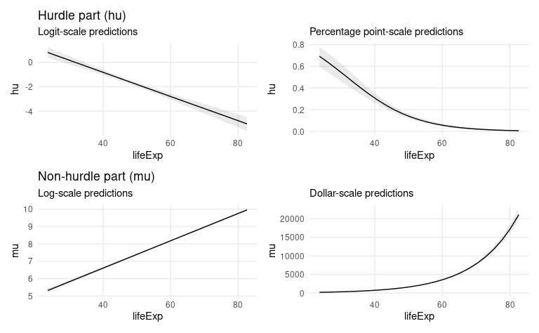

```r
plot_cap(
  mod,
  dpar = "hu",
  type = "link",
  condition = "lifeExp") +
  labs(y = "hu",
       title = "Hurdle part (hu)",
       subtitle = "Logit-scale predictions") +
plot_cap(
  mod,
  dpar = "hu",
  type = "response",
  condition = "lifeExp") +
  labs(y = "hu",
       subtitle = "Percentage point-scale predictions") +
plot_cap(
  mod,
  dpar = "mu",
  condition = "lifeExp") +
  labs(y = "mu",
       title = "Non-hurdle part (mu)",
       subtitle = "Log-scale predictions") +
plot_cap(
  mod,
  dpar = "mu",
  transform_post = exp,
  condition = "lifeExp") +
  labs(y = "mu",
       subtitle = "Dollar-scale predictions")
```

For **marginal effects**, we need to transform the predictions *before* calculating the instantaneous slopes. We also can’t use the `marginaleffects()` function directly—we need to use `comparisons()` and compute the numerical derivative ourselves (i.e. predict `gdpPercap` at `lifeExp` of 40 and 40.001 and calculate the slope between those predictions). We can use the `transform_pre` argument to pass the pair of predicted values to `exp()` before calculating the slopes:

```r
# step size of the numerical derivative
eps <- 0.001

comparisons(
  mod,
  dpar = "mu",
  variables = list(lifeExp = eps),
  newdata = datagrid(lifeExp = seq(40, 80, 20)),
  # rescale the elements of the slope
  # (exp(40.001) - exp(40)) / exp(0.001)
  transform_pre = function(hi, lo) ((exp(hi) - exp(lo)) / exp(eps)) / eps
)
```

```
#>   rowid     type    term contrast comparison   conf.low  conf.high
#> 1     1 response lifeExp   custom   58.39448   55.84743   61.02206
#> 2     2 response lifeExp   custom  280.89410  266.57621  295.50894
#> 3     3 response lifeExp   custom 1349.40503 1222.58608 1490.38119
#>   predicted predicted_hi predicted_lo lifeExp       eps
#> 1  6.612435     6.612474     6.612396      40 0.0059004
#> 2  8.183520     8.183559     8.183481      60 0.0059004
#> 3  9.753512     9.753551     9.753473      80 0.0059004
```

We can visually confirm that these are the instantaneous slopes at each of these levels of life expectancy:

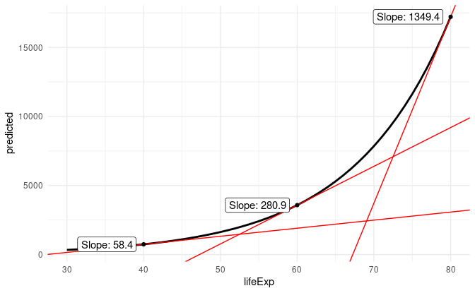

```r
predictions_data <- predictions(
  mod,
  newdata = datagrid(lifeExp = seq(30, 80, 1)),
  dpar = "mu",
  transform_post = exp
)

slopes_data <- comparisons(
  mod,
  dpar = "mu",
  variables = list(lifeExp = eps),
  newdata = datagrid(lifeExp = seq(40, 80, 20)),
  transform_pre = function(hi, lo) ((exp(hi) - exp(lo)) / exp(eps)) / eps
) %>%
  select(lifeExp, comparison) %>%
  left_join(predictions_data, by = "lifeExp") %>%
  # Point-slope formula: (y - y1) = m(x - x1)
  mutate(intercept = comparison * (-lifeExp) + predicted)

ggplot(predictions_data, aes(x = lifeExp, y = predicted)) +
  geom_line(size = 1) +
  geom_abline(data = slopes_data, aes(slope = comparison, intercept = intercept),
              size = 0.5, color = "red") +
  geom_point(data = slopes_data) +
  geom_label(data = slopes_data, aes(label = paste0("Slope: ", round(comparison, 1))),
             nudge_x = -1, hjust = 1) +
  theme_minimal()
```